# Evaluación del aprendizaje

El primer paso de la próxima etapa

Ph.D. Pablo Eduardo Caicedo Rodríguez

2026-01-21

## Introducción

**Definición**

Un aprendizaje que perdura es un proceso **activo, profundamente conectado y estratégicamente practicado** que produce **cambio conceptual** estable, **dominio** de habilidades y **transferencia** a contextos nuevos.

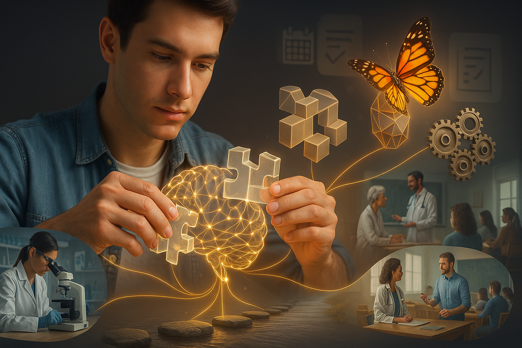

Generada mediante CHATGPT

## Introducción

**Tres pilares**

- **Comprensión profunda y organización significativa del conocimiento**: integración con conocimientos previos y estructuras ricas (no listas de hechos aislados).
- **Prácticas con “dificultades deseables”**: especialmente **recuperación**, **espaciado** e **entrelazado**.
- **Evaluación formativa y retroalimentación orientadora**: ciclos breves y frecuentes que guían el ajuste de estrategias.

## Introducción

**Tres pilares**

- **Comprensión profunda y organización significativa del conocimiento**.
- Prácticas con “dificultades deseables”.
- Evaluación formativa y retroalimentación orientadora.

**Implicaciones**

- Estructura: conceptos, principios y procedimientos interconectados (mapas mentales densos, no “ítems sueltos”).
- Sentido: las nuevas ideas se integran con experiencias y saberes previos mediante analogías, contraejemplos, límites de validez.
- Uso: el alumno explica, predice y resuelve en contextos nuevos, justificando por qué un método aplica y otro no.

## Una rúbrica muy básica

| Criterio | 4 Excelente | 3 Adecuado | 2 Básico | 1 Insuficiente |
| --- | --- | --- | --- | --- |
| **Estructura conceptual** | Red de conceptos y relaciones **correctas y no triviales**; incluye **condiciones y límites** | Mapa correcto con **algunas** relaciones clave | Lista de conceptos con **pocas** conexiones | Datos sueltos, conexiones erróneas |
| **Justificación** | Selecciona y **defiende** el método por **principio** | Selecciona y justifica parcialmente | Selecciona por “receta” | Selección arbitraria |
| **Transferencia** | Resuelve **nuevos contextos** y explica analogías/diferencias | Resuelve variaciones cercanas | Solo contextos vistos | No transfiere |
| **Revisión de ideas** | Identifica y **repara** concepciones previas | Reconoce algunas inconsistencias | Minimiza o ignora conflictos | Mantiene ideas erróneas |

## Introducción

**Tres pilares**

- Comprensión profunda y organización significativa del conocimiento.
- **Prácticas con “dificultades deseables”**.
- Evaluación formativa y retroalimentación orientadora.

**Implicaciones**

Las prácticas con “dificultades deseables” son retos cognitivos intencionalmente introducidos en la práctica que aumentan el esfuerzo de procesamiento y recuperación sin impedir el progreso. Ese esfuerzo óptimo provoca mejor retención, transferencia y discriminación que las prácticas fáciles (p. ej., relectura pasiva).

En términos instructivos: diseñar actividades que obliguen a reconstruir, recuperar, variar y decidir, en lugar de reconocer o repetir.

## Introducción

**Tres pilares**

- Comprensión profunda y organización significativa del conocimiento.
- Prácticas con “dificultades deseables”.
- **Evaluación formativa y retroalimentación orientadora**.

**Implicaciones**

Evaluación formativa es el proceso continuo y planificado de recoger evidencias del aprendizaje durante la enseñanza para tomar decisiones inmediatas (docente y estudiantes) que mejoren el rendimiento y la comprensión.

La retroalimentación orientadora es la información que, a partir de esas evidencias, ubica al estudiante frente a criterios explícitos (dónde está), explica la brecha (qué falta) y señala próximos pasos concretos (cómo mejorar), en el momento oportuno para que pueda actuar.

**Regla de oro**

Si la “evaluación” no cambia decisiones inmediatas de enseñanza-aprendizaje, no es formativa.

## Ciclo operativo (docente y estudiante)

- Clarificar metas/criterios (ejemplos, rubricas).
- Elicitar evidencia breve (actividad/quiz/producción).
- Analizar rápidamente contra criterios (errores típicos, patrones).
- Retroalimentar (específica, oportuna, accionable).
- Cerrar el ciclo: reintentos, revisión, práctica adicional (espaciada/entrelazada).

## *Marco de diseño*

[figure not shown]

# Que LLM usar?

# Como Usar los LLM

## Referencias

- Angelo, T. A., & Cross, K. P. (1993). Classroom assessment techniques: A handbook for college teachers (2. ed). Jossey-Bass.
- Biggs, J. B., & Tang, C. S. (with Society for Research into Higher Education). (2011). Teaching for quality learning at university: What the student does (4th edition). McGraw-Hill/Society for Research into Higher Education/Open University Press.
- Brookhart, S. M. (s. f.). How to Create and Use Rubrics for Formative Assessment and Grading.
- Felder, R. M., & Brent, R. (2016). Teaching and learning STEM: A practical guide (First edition). Jossey-Bass, A Wiley Brand.
- Hughes, C. (2025). Changing Assessment: How to Design Curriculum for Human Flourishing. BRILL. https://doi.org/10.1163/9789004714205
- Lang, J. M. (2021). Small teaching: Everyday lessons from the science of learning (Second edition). Jossey-Bass, a Wiley Brand.
- Lovett, M. C. (with Bridges, M. W., DiPietro, M., Ambrose, S. A., & Norman, M. K.). (2023). How Learning Works: Eight Research-Based Principles for Smart Teaching (2nd ed). John Wiley & Sons, Incorporated.
- McMillan, J. H. (2024). Classroom assessment: Principles and practice that enhance student learning and motivation (Eighth edition). Pearson Education, Inc.